# 2nd July

Anna Hutchinson

### Transforming q

In this weeks summary, I use iteration 2 as the application throughout, where $p=v1$ from the first iteration and $q2=dim5$ from the PCAmix results.

Dimension 5 picks out promoter regions:

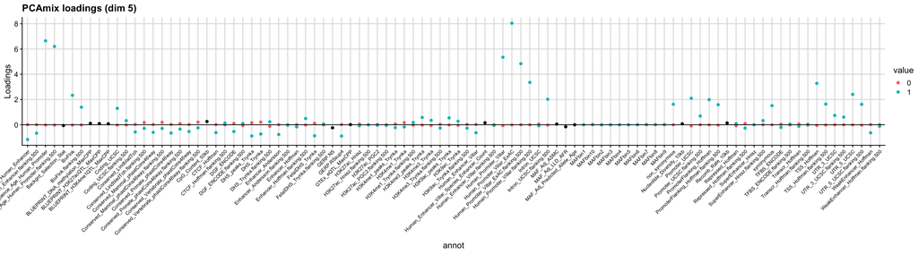

However, even though dimension 5 is picked as most significant, it is not monotonic in $p$.

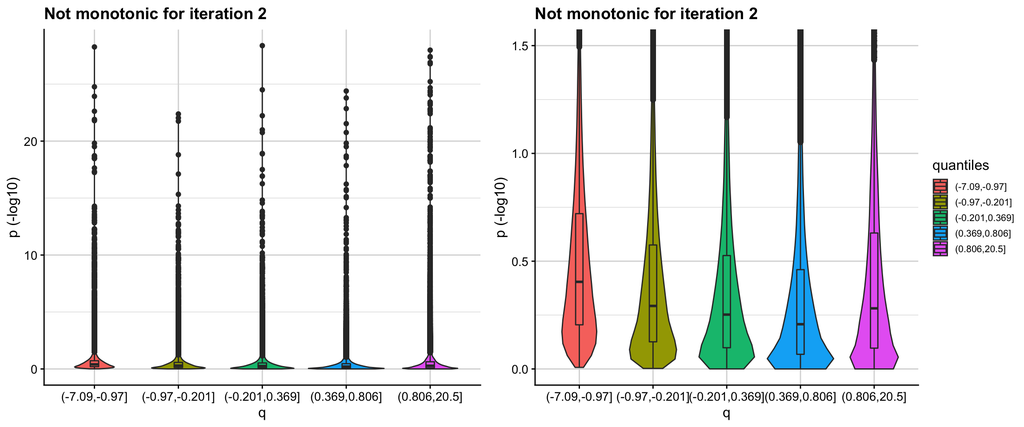

To make $q$ monotonic, we fit a spline to find the inflection point (nadir) and fold the distribution at this point. Specifically, we seperate $q$ into pre- and post- nadir and take the difference. This means that we can scale each side seperately if we so wish.

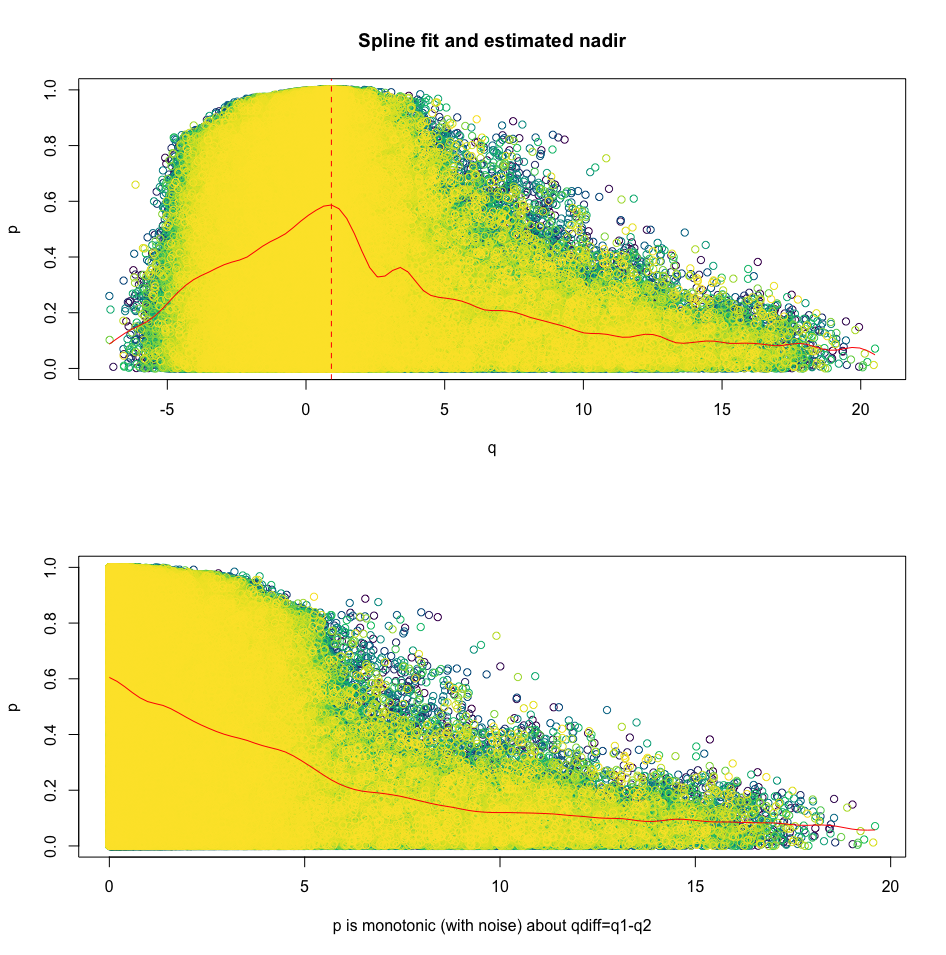

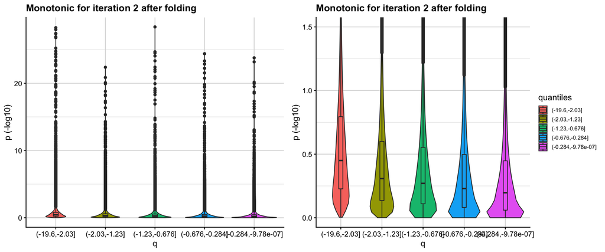

When using this transformed $q$ in our method, the results look ok. Although it looks like some spline correction is required, and that things are getting shrunk too much/ too little.

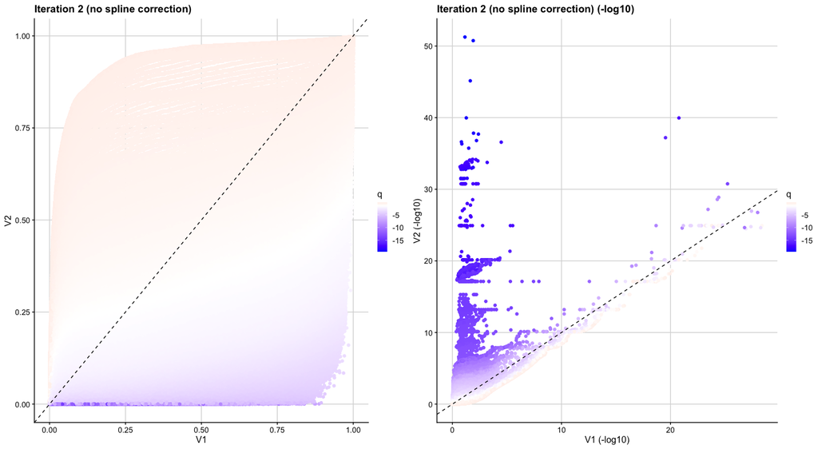

I consider the spline correction method for this iteration. A spline with `nknots=5` arbitrarily chosen is shown in red. It would be nice to use the SEs of the fit to decide parameter values.

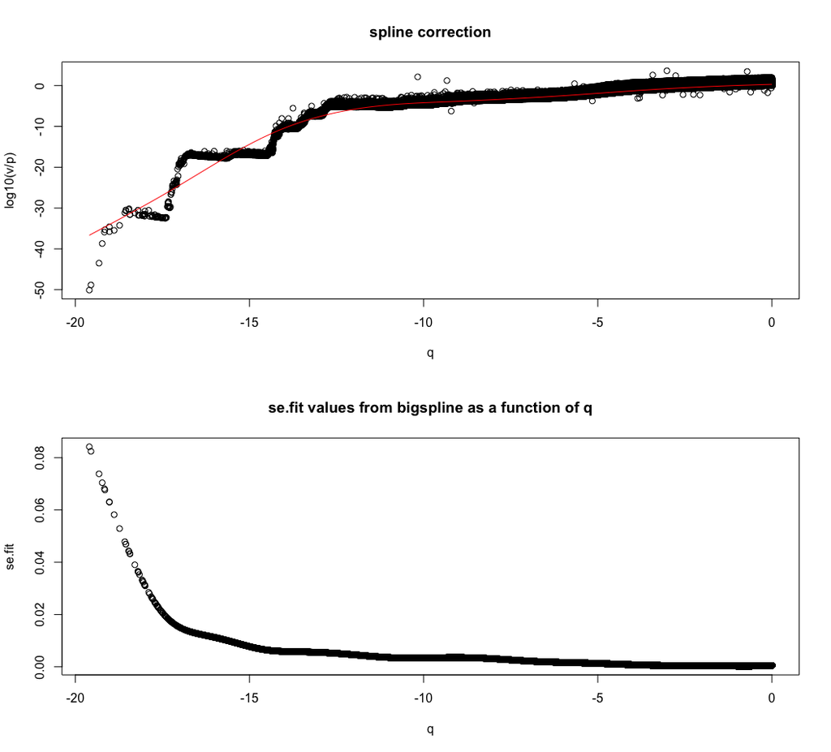

### Full method

Set $v0$ equal to the original $p$-values for the principal trait and $i=1$:

1. Regress log($v[i-1]$) against the coordinates from `PCAmix` (removing $qj$ for $j<i$)
2. Set $qi$ equal to the `PCAmix` co-ordinates from the dimension giving the largest absolute t-statistic (stop if nothing is significant)
3. Make $qi$ monotonic in $v[i-1]$
4. Perform functional cFDR on $(v[i-1], qi)$ to obtain $vi$. Set $i=i+1$ and go to step 1.

### Comments and queries

- I’ve used exp(log(x)-log(y)) when dividing two potentially small things (for kgrid and and cgrid (p/kgrid)). Nothing (visible) changed but I’ll add it in to version 5.
- Shared controls: James found that approximating $P(P\leq p|H_0^p, Q\leq q)$ by $p$ is biased when there are shared controls (and derived a new approximation that allows for shared controls). I assume I’m fine to use $p$ here? (https://journals.plos.org/plosgenetics/article?id=10.1371/journal.pgen.1004926)
- Leave-one-out: James’ new paper states that a leave-one-out method must be used for $P(v\leq \alpha)\leq \alpha$ to hold, but I am not using a leave-one-out method? (bottom of page 7; https://www.biorxiv.org/content/10.1101/414318v3.full.pdf)
- Difficulty writing up L-curve section. James talks about adding test points and convergence etc (page 7; https://www.biorxiv.org/content/10.1101/414318v3.full.pdf) but am I ok to just say that the L curves are the contours of our estimated cFDR curves?
- What would be an example of the wider non-disease specific structure/variability picked out by non-significant dimensions?
- Monotonicity stuff: Am I correct to say that the cFDR framework requires a roughly monotonic relationship between p and q? Or is it that it requires an absence of non-monotonicity (because it works for independent p and q)??
- Manuscript: Am I ok to only compare our method to FINDOR (which they found to be better than S-FDR, GBH, IHW and GenoWap)? Perhaps I could also compare to GenoWAP, their software looks easy-ish to use and I can use their GenoCanyon scores for my method too. (https://github.com/rlpowles/GenoWAP-V1.2)
- Manuscript: Need a simulation section. Basic idea: Simulate a GWAS using simGWAS (specifying CVs, effect sizes and sample sizes) using e.g. 1000 Genomes haplotype data. In FINDOR “To induce functional enrichment, we altered the prior probability that a SNP was selected to be causal, setting this to be proportional to $Var(\beta_j)=\sum_C C(j) \tau_c$ where $\tau_c$ is the effect size of annotation c.” (https://www.sciencedirect.com/science/article/pii/S0002929718304117)